# Reproducible Research: Peer Assessment 1

## Loading and preprocessing the data

- Load the data

```r
# The assumption is that the required data (activity.zip) is present in the
# working directory.
unzip("activity.zip")
activity <- read.csv("activity.csv")
```

- Process/transform the data into a format suitable for your analysis

```r
good <- complete.cases(activity)
activity_full_data <- activity[good, ]
# Process the data to get the plots we want
steps_date <- aggregate(steps ~ date, activity_full_data, sum)
summary(steps_date)
```

```
##          date        steps
##  2012-10-02: 1   Min.   :   41
##  2012-10-03: 1   1st Qu.: 8841
##  2012-10-04: 1   Median :10765
##  2012-10-05: 1   Mean   :10766
##  2012-10-06: 1   3rd Qu.:13294
##  2012-10-07: 1   Max.   :21194
##  (Other)   :47
```

## What is mean total number of steps taken per day?

- Histogram of the total number of steps taken each day

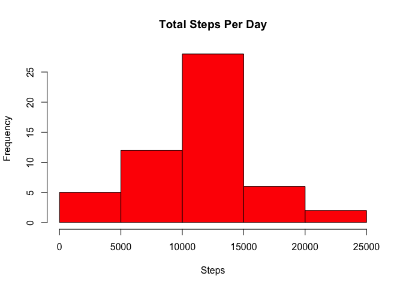

```r
hist(steps_date$steps, col = "red", main = "Total Steps Per Day",
                xlab = "Steps")
```

- Calculate and report the mean and median total number of steps taken per day

```r
steps_mean <- mean(steps_date$steps)
steps_median <- median(steps_date$steps)
```

- Mean total number of steps taken per day is:

```r
steps_mean
```

```
## [1] 10766
```

- Median of total number of steps taken per day is:

```r
steps_median
```

```
## [1] 10765
```

## What is the average daily activity pattern?

- Time series plot (i.e. type = “l”) of the 5-minute interval (x-axis) and the average number of steps taken, averaged across all days (y-axis)

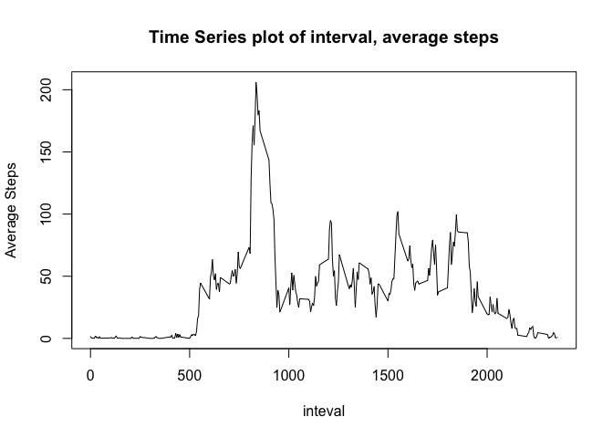

```r
plot_data <- aggregate(steps ~ interval, activity_full_data, mean)
plot(plot_data$interval, plot_data$steps, type = "l", xlab = "inteval",
    ylab = "Average Steps", main="Time Series plot of interval, average steps")
```

- The 5-minute interval, on average across all the days in the dataset that contains the maximum number of steps is:

```r
plot_data[(plot_data$steps == max(plot_data$steps)), ]$interval
```

```
## [1] 835
```

## Imputing missing values

- The total number of missing values in the dataset

```r
nrow(activity[!good, ])
```

```
## [1] 2304
```

Using the mean for 5-minute intervals for filling in all of the missing values in the dataset

```r
missing_value_entries <- activity[!good, ]
fill_missing_values <- merge(missing_value_entries, plot_data,
                                by.x="interval", by.y="interval", all.x = TRUE)
fill_missing_values$steps.x <- fill_missing_values$steps.y
fill_missing_values <- fill_missing_values[c("steps.x", "date","interval")]
```

- Create a new dataset that is equal to the original dataset but with the missing data filled in

```r
full_data <- merge(activity, fill_missing_values, by.x=c("interval", "date"),
                    by.y=c("interval", "date"), all.x=TRUE)
full_data[is.na(full_data$steps), ]$steps <-
                        full_data[!is.na(full_data$steps.x), ]$steps.x
full_data <- full_data[c("steps", "date","interval")]
nrow(full_data[is.na(full_data$steps), ])
```

```
## [1] 0
```

- Make a histogram of the total number of steps taken each day and Calculate and report the mean and median total number of steps taken per day

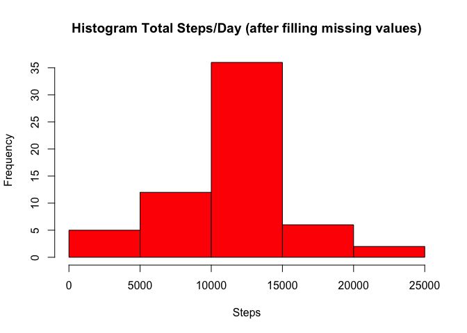

```r
steps_date <- aggregate(steps ~ date, full_data, sum)
hist(steps_date$steps, col = "red",
            main = "Histogram Total Steps/Day (after filling missing values)",
            xlab = "Steps")
```

- Mean =>

```r
mean(steps_date$steps)
```

```
## [1] 10766
```

- Median =>

```r
median(steps_date$steps)
```

```
## [1] 10766
```

## Are there differences in activity patterns between weekdays and weekends?

- Create a new factor variable in the dataset with two levels “weekday” and “weekend” indicating whether a given date is a weekday or weekend day

```r
full_data$weekdays <- weekdays(as.Date(full_data$date, format="%Y-%m-%d"))
full_data$weekdays <- ifelse(full_data$weekdays == "Saturday" |
                        full_data$weekdays == "Sunday", "weekend", "weekday")
full_data$weekdays <- as.factor(full_data$weekdays)
class(full_data$weekdays)
```

```
## [1] "factor"
```

- Make a panel plot containing a time series plot (i.e. type = “l”) of the 5-minute interval (x-axis) and the average number of steps taken, averaged across all weekday days or weekend days (y-axis).

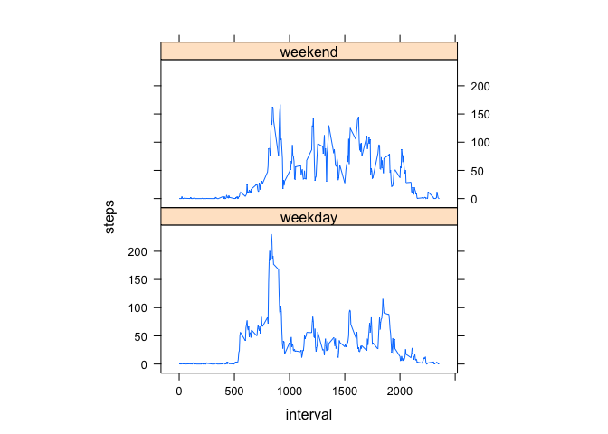

```r
plot_data <- aggregate(steps ~ interval + weekdays, full_data, mean)
library(lattice)
xyplot(steps ~ interval | factor(weekdays), plot_data, aspect = 1/2, type = "l")
```